# Homework 03

Author

Prerith Arunkumar (prerith2)

Ridge regression under near-collinearity, what the penalty shrinks in the singular-value basis, the optimization geometry of the ridge objective, and penalty selection by cross-validation and GCV.

**Show the workflow**

```python
import numpy as np
import pandas as pd
import matplotlib.pyplot as plt

np.set_printoptions(precision=6, suppress=True)
pd.set_option("display.width", 120)
```

## Question 1 (Build an `explain-to-me` skill)

I wrote `explain-to-me/SKILL.md` (full contents in the final section) and installed it as a project-level Claude Code skill at `.claude/skills/explain-to-me/SKILL.md`. The design choices were:

- **Trigger only on an explicit request.** The skill states that it runs only when I say “use `explain-to-me` on Question N”, so it does not change how the agent behaves the rest of the time. This was the main thing I wanted to protect: a skill that fires on every homework question would be a nuisance.
- **Explain, do not solve.** No code, no derivations, no numbers, no “expected results”. The skill tells the agent to refuse those and stop if asked, and not to open the solutions file.
- **A fixed output shape.** Goal in plain words, a checklist of deliverables, the inputs I must get right (seeds, scaling conventions, $n\lambda$ versus $\lambda$), a pointer to a specific lecture section, and one check-your-understanding question back to me.

**Test.** I asked the agent to “use `explain-to-me` to read and explain Question 2”. The response, lightly trimmed:

> **Goal.** Question 2 builds two predictors that are almost the same variable ($X_1$ and $X_2$ share $L$ and differ only by $0.04$ times independent noise), then asks what happens to least squares and to ridge when the design is nearly singular. The point is to see instability in the individual slopes that does not show up in the fitted values.

> **Deliverables.** (a) One standardized $\mathbf X$; its column-1/column-2 correlation and its largest and smallest singular values; an explanation of why $\widehat\beta_1-\widehat\beta_2$ is much noisier than $\widehat\beta_1+\widehat\beta_2$. (b) 200 repetitions of $(\mathbf y,\mathbf y^*)$ with $\mathbf X$ fixed; for each $\lambda\in\{0,0.02,0.2\}$ the mean and sd of $\widehat\beta_1$, $\widehat\beta_2$, their sum and difference, plus average training and test MSE. (c) A bias/variance interpretation of the table.

> **Inputs to get right.** Seed 43231 set once before the design. Standardize with the *population* scale (divide by $n$), so each column has average squared value one. Ridge uses $n\lambda$ inside the inverse. The intercept is $\bar y$, unpenalized, and is added back for both responses. Draw the noise pair once per repetition and reuse it for all three $\lambda$; do not redraw $\mathbf X$.

> **Where to read.** *Ridge Regression: Stability Through Shrinkage*, the section on the singular-value view of the variance of $\widehat{\boldsymbol\beta}$: the smallest singular value controls the variance along the direction it spans, which here is the $(1,-1,0,0)$ direction.

> **Check.** Before running anything, can you say what the singular vector for the smallest singular value should look like, and why $(\widehat\beta_1+\widehat\beta_2)$ does not depend on it?

This did what I wanted: it named the two conventions I would most likely have gotten wrong ($n\lambda$ and the $1/n$ scale) without giving away any results, and the closing question was the right one to think about before part (a). I kept the skill installed; it did not disturb any other work because it only responds to an explicit request.

## Question 2 (Ridge regression with nearly collinear predictors)

### (a) The fixed design

**Show the workflow**

```python
rng = np.random.default_rng(43231)
n, p = 100, 4

L  = rng.normal(size=n)
U1 = rng.normal(size=n)
U2 = rng.normal(size=n)
X3 = rng.normal(size=n)
X4 = rng.normal(size=n)

X_raw = np.column_stack([L + 0.04 * U1, L + 0.04 * U2, X3, X4])
X = (X_raw - X_raw.mean(axis=0)) / X_raw.std(axis=0, ddof=0)   # mean 0, average squared value 1

corr12 = np.corrcoef(X[:, 0], X[:, 1])[0, 1]
U_svd, d, Vt = np.linalg.svd(X, full_matrices=False)

print(f"corr(X1, X2)            = {corr12:.5f}")
print(f"singular values          = {d}")
print(f"largest / smallest       = {d[0]:.4f} / {d[-1]:.4f}   (ratio {d[0] / d[-1]:.1f})")
print(f"right singular vector v4 = {Vt[-1]}")
```

```
corr(X1, X2)            = 0.99833
singular values          = [14.172962 10.646427  9.252882  0.406094]
largest / smallest       = 14.1730 / 0.4061   (ratio 34.9)
right singular vector v4 = [ 0.707259 -0.706941  0.000297  0.004332]
```

The first two columns have correlation $0.9983$. The singular values of the standardized $\mathbf X$ are $d_1 = 14.17$, $d_2 = 10.65$, $d_3 = 9.25$ and $d_4 = 0.406$, so the design is almost rank three. The right singular vector for $d_4$ is essentially $(1,-1,0,0)/\sqrt 2$, the contrast direction.

**Why the difference is unstable and the sum is not.** With $\lambda=0$, the OLS slopes are $\widehat{\boldsymbol\beta} = \mathbf V\mathbf D^{-1}\mathbf U^{\mathsf T}\widetilde{\mathbf y}$, so for any unit vector $\mathbf w$,
$$\operatorname{Var}(\mathbf w^{\mathsf T}\widehat{\boldsymbol\beta}) = \sigma^2\sum_{j=1}^4 \frac{(\mathbf w^{\mathsf T}\mathbf v_j)^2}{d_j^2}.$$
Take $\mathbf w = (1,-1,0,0)/\sqrt 2$. It is (almost exactly) $\mathbf v_4$, so the variance of the contrast is $\sigma^2/d_4^2 = 1/0.165 \approx 6.06$ per unit-norm contrast, i.e. $\operatorname{Var}(\widehat\beta_1-\widehat\beta_2)\approx 2\times 6.06 = 12.1$, standard deviation about $3.5$. Take $\mathbf w = (1,1,0,0)/\sqrt 2$ instead. It is orthogonal to $\mathbf v_4$ and lies in the span of the large-singular-value directions, so its variance is on the order of $\sigma^2/d_1^2 \approx 0.005$ per unit norm, giving $\operatorname{Var}(\widehat\beta_1+\widehat\beta_2)\approx 0.01$, standard deviation about $0.1$. The ratio of the two standard deviations should be roughly $d_1/d_4 \approx 35$. Geometrically: the data tell us very precisely what $X_1+X_2$ (which is $\approx 2L$) does to $y$, and almost nothing about how to split that effect between two columns that are indistinguishable.

### (b) 200 repetitions with $\mathbf X$ fixed

**Show the workflow**

```python
beta_true = np.array([1.5, 1.5, 1.0, 0.0])
mu = X @ beta_true
lambdas = [0.0, 0.02, 0.2]
n_sim = 200

# (X'X + n*lambda*I)^{-1} X' depends only on X and lambda, so precompute it once per lambda
ridge_op = {lam: np.linalg.solve(X.T @ X + n * lam * np.eye(p), X.T) for lam in lambdas}

records = {lam: np.zeros((n_sim, 6)) for lam in lambdas}
for r in range(n_sim):
    y      = mu + rng.normal(size=n)      # one training / test noise pair per repetition ...
    y_star = mu + rng.normal(size=n)
    beta0  = y.mean()
    y_tilde = y - beta0
    for lam in lambdas:                   # ... reused for all three lambda
        b = ridge_op[lam] @ y_tilde
        fit = beta0 + X @ b
        records[lam][r] = [b[0], b[1], b[0] + b[1], b[0] - b[1],
                           np.mean((y - fit) ** 2), np.mean((y_star - fit) ** 2)]

rows = []
for lam in lambdas:
    R = records[lam]
    m, s = R.mean(axis=0), R.std(axis=0, ddof=1)
    rows.append({"lambda": lam,
                 "b1 mean": m[0], "b1 sd": s[0],
                 "b2 mean": m[1], "b2 sd": s[1],
                 "b1+b2 mean": m[2], "b1+b2 sd": s[2],
                 "b1-b2 mean": m[3], "b1-b2 sd": s[3],
                 "train MSE": m[4], "test MSE": m[5]})
tab2 = pd.DataFrame(rows).set_index("lambda")
tab2.round(4)
```

| lambda | b1 mean | b1 sd | b2 mean | b2 sd | b1+b2 mean | b1+b2 sd | b1-b2 mean | b1-b2 sd | train MSE | test MSE |
| --- | --- | --- | --- | --- | --- | --- | --- | --- | --- | --- |
| 0.00 | 1.2901 | 1.7951 | 1.7014 | 1.7979 | 2.9915 | 0.1049 | -0.4113 | 3.5915 | 0.9493 | 1.0384 |
| 0.02 | 1.4645 | 0.1447 | 1.4968 | 0.1479 | 2.9613 | 0.1039 | -0.0323 | 0.2735 | 0.9597 | 1.0292 |
| 0.20 | 1.3553 | 0.0494 | 1.3593 | 0.0504 | 2.7146 | 0.0954 | -0.0041 | 0.0293 | 1.0639 | 1.1253 |

The truth is $\beta_1=\beta_2=1.5$, so $\beta_1+\beta_2=3$ and $\beta_1-\beta_2=0$.

### (c) Interpretation

**Individual coefficients: variance collapses, a little bias appears.** At $\lambda=0$ the OLS estimates of $\beta_1$ and $\beta_2$ are unbiased in principle but have standard deviation $\approx 1.8$ each, and the contrast $\widehat\beta_1-\widehat\beta_2$ has standard deviation $3.6$, matching the $\sigma/d_4$ calculation in (a). Their 200-run means ($1.29$ and $1.70$) are off from $1.5$ only because a standard deviation of $1.8$ makes a 200-run mean uncertain by about $0.13$. At $\lambda=0.02$, the contrast sd drops from $3.6$ to $0.27$ (a factor of 13) and the individual slope sds from $1.8$ to $0.15$, while the means stay within Monte Carlo error of $1.5$. At $\lambda=0.2$, the sds fall further (to $0.05$), but now a visible bias appears: the sum is estimated at $2.71$ rather than $3$, and $\widehat\beta_1,\widehat\beta_2\approx1.36$. The sum $\widehat\beta_1+\widehat\beta_2$ was already stable under OLS (sd $0.10$) and ridge barely changes its sd; what ridge does to the sum is shrink it, which is pure bias.

**Fitted values: a much smaller story.** Training MSE rises from $0.949$ to $0.960$ to $1.064$, and test MSE goes $1.038 \to 1.029 \to 1.125$. The ridge fit at $\lambda=0.02$ is better on test data than OLS, but only by about $0.01$, even though the coefficient standard deviations dropped by a factor of 12. At $\lambda=0.2$ the bias from shrinking the strong $X_1+X_2$ direction costs about $0.09$ in test MSE.

**Why the two scales are so different.** Write $\widehat{\boldsymbol\beta}$ in the singular basis. The unstable part of OLS lives entirely in the $\mathbf v_4$ direction; its coefficient has variance $\sigma^2/d_4^2\approx 6$. But the fitted values are $\mathbf X\widehat{\boldsymbol\beta}$, and $\mathbf X\mathbf v_4 = d_4\mathbf u_4$ has length only $d_4 = 0.406$. So a coefficient error of size $\sqrt6\approx2.5$ along $\mathbf v_4$ moves the fitted vector by $0.406\times 2.5\approx 1$ in total, or about $1/\sqrt{100} = 0.1$ per observation, which is $0.01$ in squared units: exactly the test-MSE gap between OLS and $\lambda=0.02$. The design multiplies the noisy coefficient direction by a tiny number precisely because that direction is the one the data cannot see. Ridge shrinks that direction almost to zero ($\rho_4(0.02) = d_4^2/(d_4^2+2) = 0.076$) while leaving the three strong directions nearly untouched ($\rho_1(0.02)=0.990$), so it removes almost all coefficient variance and almost no signal. Per direction, the variance of the fitted component is $\sigma^2\rho_j^2$ and the bias is $(1-\rho_j)\,\mathbf u_j^{\mathsf T}\boldsymbol\mu$; at $\lambda=0.2$ the factor for the strong directions drops to $\rho_1 \approx 0.91$ and the squared bias on the signal starts to dominate, which is why test MSE turns up.

## Question 3 (What does ridge regression shrink?)

### (a) The ridge normal equation

Expand the objective:
$$L_\lambda(\boldsymbol\beta)=\frac{1}{2n}\left(\widetilde{\mathbf y}^{\mathsf T}\widetilde{\mathbf y}-2\boldsymbol\beta^{\mathsf T}\mathbf X^{\mathsf T}\widetilde{\mathbf y}+\boldsymbol\beta^{\mathsf T}\mathbf X^{\mathsf T}\mathbf X\boldsymbol\beta\right)+\frac{\lambda}{2}\boldsymbol\beta^{\mathsf T}\boldsymbol\beta .$$
Its gradient is
$$\nabla L_\lambda(\boldsymbol\beta)=\frac1n\left(\mathbf X^{\mathsf T}\mathbf X\boldsymbol\beta-\mathbf X^{\mathsf T}\widetilde{\mathbf y}\right)+\lambda\boldsymbol\beta
=\frac1n\left[\left(\mathbf X^{\mathsf T}\mathbf X+n\lambda\mathbf I_p\right)\boldsymbol\beta-\mathbf X^{\mathsf T}\widetilde{\mathbf y}\right].$$
Setting it to zero gives $\left(\mathbf X^{\mathsf T}\mathbf X+n\lambda\mathbf I_p\right)\widehat{\boldsymbol\beta}_\lambda=\mathbf X^{\mathsf T}\widetilde{\mathbf y}$. The Hessian is $\frac1n\mathbf X^{\mathsf T}\mathbf X+\lambda\mathbf I_p$.

**Uniqueness for $\lambda>0$.** $\mathbf X^{\mathsf T}\mathbf X$ is positive semidefinite: $\mathbf z^{\mathsf T}\mathbf X^{\mathsf T}\mathbf X\mathbf z=\lVert\mathbf X\mathbf z\rVert^2\ge0$. Hence for any $\mathbf z\ne\mathbf 0$,
$$\mathbf z^{\mathsf T}\left(\mathbf X^{\mathsf T}\mathbf X+n\lambda\mathbf I_p\right)\mathbf z=\lVert\mathbf X\mathbf z\rVert^2+n\lambda\lVert\mathbf z\rVert^2\ \ge\ n\lambda\lVert\mathbf z\rVert^2>0 .$$
So $\mathbf X^{\mathsf T}\mathbf X+n\lambda\mathbf I_p$ is positive definite, hence invertible, regardless of the rank of $\mathbf X$ and regardless of whether $p>n$. Equivalently, its eigenvalues are $d_j^2+n\lambda\ge n\lambda>0$ (with $d_j=0$ for the null directions). The objective is then strictly convex, so the stationary point is the unique global minimizer. Without the penalty, any $\mathbf z$ in the null space of $\mathbf X$ (which is nontrivial when $p>n$ or the columns are dependent) leaves $L_0$ unchanged, so OLS has infinitely many minimizers.

### (b) Shrinkage in the singular basis

Substitute $\mathbf X=\mathbf U_r\mathbf D_r\mathbf V_r^{\mathsf T}$, with $\mathbf U_r^{\mathsf T}\mathbf U_r=\mathbf V_r^{\mathsf T}\mathbf V_r=\mathbf I_r$. Then $\mathbf X^{\mathsf T}\mathbf X=\mathbf V_r\mathbf D_r^2\mathbf V_r^{\mathsf T}$ and $\mathbf X^{\mathsf T}\widetilde{\mathbf y}=\mathbf V_r\mathbf D_r\mathbf U_r^{\mathsf T}\widetilde{\mathbf y}$. Complete $\mathbf V_r$ to an orthonormal basis $\mathbf V=[\mathbf V_r\ \mathbf V_\perp]$ of $\mathbb R^p$; on $\mathbf V_\perp$ the matrix $\mathbf X^{\mathsf T}\mathbf X+n\lambda\mathbf I$ acts as $n\lambda\mathbf I$ and $\mathbf X^{\mathsf T}\widetilde{\mathbf y}$ has no component, so $\widehat{\boldsymbol\beta}_\lambda$ has no component there. On the range of $\mathbf V_r$,
$$\widehat{\boldsymbol\beta}_\lambda=\mathbf V_r\left(\mathbf D_r^2+n\lambda\mathbf I_r\right)^{-1}\mathbf D_r\mathbf U_r^{\mathsf T}\widetilde{\mathbf y}.$$
The fitted response is therefore
$$\widehat{\mathbf y}_\lambda=\mathbf X\widehat{\boldsymbol\beta}_\lambda=\mathbf U_r\mathbf D_r\left(\mathbf D_r^2+n\lambda\mathbf I_r\right)^{-1}\mathbf D_r\mathbf U_r^{\mathsf T}\widetilde{\mathbf y}
=\sum_{j=1}^r\frac{d_j^2}{d_j^2+n\lambda}\,\mathbf u_j\left(\mathbf u_j^{\mathsf T}\widetilde{\mathbf y}\right).$$
OLS ($\lambda=0$) keeps the full projection $\mathbf u_j(\mathbf u_j^{\mathsf T}\widetilde{\mathbf y})$ in each direction; ridge multiplies the $j$th one by $\rho_j(\lambda)=d_j^2/(d_j^2+n\lambda)\in(0,1)$. The hat matrix is $\mathbf H_\lambda=\mathbf U_r\operatorname{diag}(\rho_j)\mathbf U_r^{\mathsf T}$ plus $\frac1n\mathbf 1\mathbf 1^{\mathsf T}$ for the intercept, whose trace is $1+\sum_j\rho_j$.

**Show the workflow**

```python
n3, lam3 = 100, 0.01
d3 = np.array([10.0, 2.0, 0.2])
rho = d3**2 / (d3**2 + n3 * lam3)
for dj, rj in zip(d3, rho):
    print(f"d = {dj:5.2f}   d^2 = {dj**2:7.2f}   rho = {dj**2:.2f}/({dj**2:.2f} + {n3*lam3:.0f}) = {rj:.6f}")
print(f"df_eff = 1 + {rho.sum():.6f} = {1 + rho.sum():.6f}")
```

```
d = 10.00   d^2 =  100.00   rho = 100.00/(100.00 + 1) = 0.990099
d =  2.00   d^2 =    4.00   rho = 4.00/(4.00 + 1) = 0.800000
d =  0.20   d^2 =    0.04   rho = 0.04/(0.04 + 1) = 0.038462
df_eff = 1 + 1.828561 = 2.828561
```

With $n\lambda=1$: $\rho_1 = 100/101 = 0.9901$, $\rho_2 = 4/5 = 0.8$, $\rho_3 = 0.04/1.04 = 0.0385$, and $\operatorname{df}_{\mathrm{eff}} = 1 + 0.9901 + 0.8 + 0.0385 = 2.829$. Three slopes plus an intercept would be $4$ degrees of freedom under OLS; ridge at this $\lambda$ spends a little under three.

### (c) Which direction, and why it can help or hurt

The $d_3=0.2$ direction is shrunk hardest: it keeps only $3.8\%$ of its OLS projection, while the $d_1=10$ direction keeps $99\%$. The same $n\lambda=1$ is negligible next to $d_1^2=100$ and dominant next to $d_3^2=0.04$.

**Variance reduction.** The fitted component in direction $j$ is $\rho_j\,\mathbf u_j^{\mathsf T}\widetilde{\mathbf y}$ and $\mathbf u_j^{\mathsf T}\widetilde{\mathbf y}$ has variance $\sigma^2$ for every $j$. So OLS pays $\sigma^2$ of prediction variance in each of the $r$ directions, including the ones the design barely spans. Under ridge the variance in direction $j$ becomes $\rho_j^2\sigma^2$; in the $d_3$ direction that is $0.0015\sigma^2$ instead of $\sigma^2$. In coefficient space the effect is much larger: the OLS coefficient along $\mathbf v_3$ has variance $\sigma^2/d_3^2 = 25\sigma^2$, and ridge cuts it by the factor $\rho_3^2$. A direction with small $d_j$ is one in which the predictors hardly vary, so the corresponding coefficient is determined almost entirely by noise, and discarding it costs little.

**When the same shrinkage bites.** The bias in direction $j$ is $(1-\rho_j)\,\mathbf u_j^{\mathsf T}\boldsymbol\mu$, where $\boldsymbol\mu$ is the true mean. Shrinkage is harmless only if the true signal has little projection on $\mathbf u_3$. If the true coefficient vector points along $\mathbf v_3$, so that $\boldsymbol\mu=\mathbf X\boldsymbol\beta$ has a large component $d_3(\mathbf v_3^{\mathsf T}\boldsymbol\beta)$ along $\mathbf u_3$, then ridge throws away $96\%$ of it and the squared bias $(1-\rho_3)^2(\mathbf u_3^{\mathsf T}\boldsymbol\mu)^2$ can exceed the $\sigma^2(1-\rho_3^2)$ of variance saved. Concretely: a large true coefficient on a low-variance predictor, or a true effect that depends on the *difference* of two nearly collinear predictors (as the $(1,-1)$ contrast in Question 2 would if $\beta_1\ne\beta_2$). Ridge assumes, implicitly, that directions the data cannot resolve do not carry much signal; when that prior is wrong, so is the estimate.

## Question 4 (Ridge regression and optimization)

### (a) Condition numbers

**Show the workflow**

```python
a = np.array([9.0, 0.01]); lam4 = 0.09
print(f"kappa(A_0)      = {a.max() / a.min():.2f}")
print(f"eig(A_lambda)   = {a + lam4}")
print(f"kappa(A_lambda) = {(a + lam4).max() / (a + lam4).min():.2f}")
```

```
kappa(A_0)      = 900.00
eig(A_lambda)   = [9.09 0.1 ]
kappa(A_lambda) = 90.90
```

$\kappa(\mathbf A_0) = 9/0.01 = 900$ and $\kappa(\mathbf A_\lambda) = 9.09/0.10 = 90.9$. Adding $\lambda\mathbf I$ adds the same $0.09$ to both eigenvalues, which is a $1\%$ change to the large one and a tenfold change to the small one. The level sets of a quadratic with Hessian $\mathbf A$ are ellipses with axis lengths proportional to $1/\sqrt{\text{eigenvalue}}$, so the OLS bowl has axis ratio $\sqrt{900}=30$: a long, nearly flat valley along the small-eigenvalue direction. Ridge raises the floor of that valley, giving axis ratio $\sqrt{90.9}\approx 9.5$. The objective is rounder, its minimizer is better determined along the flat direction, and, as (b) shows, gradient descent stops being limited by a ratio of $900$ between the step-size cap and the rate of progress in the slow direction.

### (b) Gradient descent as a contraction in each eigendirection

For the objective in Question 3, $\nabla L_\lambda(\boldsymbol\beta)=\mathbf A_\lambda\boldsymbol\beta-\frac1n\mathbf X^{\mathsf T}\widetilde{\mathbf y}$ and the minimizer satisfies $\mathbf A_\lambda\widehat{\boldsymbol\beta}_\lambda=\frac1n\mathbf X^{\mathsf T}\widetilde{\mathbf y}$. Subtracting, $\nabla L_\lambda(\boldsymbol\beta^{(k)})=\mathbf A_\lambda\left(\boldsymbol\beta^{(k)}-\widehat{\boldsymbol\beta}_\lambda\right)=\mathbf A_\lambda\mathbf e^{(k)}$, so
$$\mathbf e^{(k+1)}=\boldsymbol\beta^{(k+1)}-\widehat{\boldsymbol\beta}_\lambda=\mathbf e^{(k)}-\eta\mathbf A_\lambda\mathbf e^{(k)}=\left(\mathbf I-\eta\mathbf A_\lambda\right)\mathbf e^{(k)} .$$
Let $\mathbf q$ be an eigenvector of $\mathbf A_0$ with eigenvalue $a$. Then $\mathbf A_\lambda\mathbf q=(a+\lambda)\mathbf q$, and writing $\mathbf e^{(k)}=\sum c^{(k)}_q\mathbf q$ in the eigenbasis,
$$c^{(k+1)}_q=\left(1-\eta(a+\lambda)\right)c^{(k)}_q,\qquad\text{so}\qquad c^{(k)}_q=\left(1-\eta(a+\lambda)\right)^k c^{(0)}_q .$$
Every direction contracts iff $|1-\eta(a+\lambda)|<1$ for both eigenvalues, i.e. $0<\eta(a+\lambda)<2$. The binding constraint is the largest eigenvalue $M=9.09$, giving
$$0<\eta<\frac{2}{M}=\frac{2}{9.09}\approx 0.2200 .$$

**Show the workflow**

```python
M, m_ = 9.09, 0.10
for eta in [1 / M, 2.1 / M]:
    f_big, f_small = 1 - eta * M, 1 - eta * m_
    print(f"eta = {eta:.5f}: factor along M = {f_big:+.4f}, factor along 0.10 = {f_small:+.5f}, "
          f"converges = {max(abs(f_big), abs(f_small)) < 1}")
```

```
eta = 0.11001: factor along M = +0.0000, factor along 0.10 = +0.98900, converges = True
eta = 0.23102: factor along M = -1.1000, factor along 0.10 = +0.97690, converges = False
```

**$\eta = 1/M \approx 0.110$.** The factor along the stiff direction is $1-1=0$: that component of the error is eliminated in a single step. The factor along the flat direction is $1-0.10/9.09 = 0.9890$. It converges, but slowly: $0.989^k$ reaches $10^{-3}$ only after about $k=\log(10^{-3})/\log(0.989)\approx 625$ steps. The high-curvature direction converges much faster; the low-curvature direction is the one that limits the run. (Without the penalty the same step $1/9$ would give a slow factor $1-0.01/9=0.9989$, about $6{,}200$ steps to the same accuracy.)

**$\eta = 2.1/M \approx 0.231$.** The factor along the stiff direction is $1-2.1=-1.1$, so $|c^{(k)}|=1.1^k|c^{(0)}|$: with a nonzero initial component in that direction, the error oscillates in sign and grows without bound. The flat direction still contracts (factor $1-2.1\times0.10/9.09=0.9769$), but that is irrelevant: the iteration diverges. This is why the largest eigenvalue, not the average, sets the step-size ceiling.

### (c) Why fast convergence is not a tuning rule

Increasing $\lambda$ improves $\kappa(\mathbf A_\lambda)$ monotonically and makes gradient descent converge faster; in the limit $\lambda\to\infty$ the condition number goes to $1$ and the iteration converges in one step, to $\widehat{\boldsymbol\beta}_\lambda=\mathbf 0$. That is the problem. The value of $\lambda$ *defines the estimator*; it changes which function of the data we are computing, and hence its bias and variance. The step size $\eta$ and the number of iterations define an *algorithm* for computing that estimator; they affect how much arithmetic it takes to reach $\widehat{\boldsymbol\beta}_\lambda$ to a given tolerance, and nothing about the statistical quality of $\widehat{\boldsymbol\beta}_\lambda$ itself. Choosing $\lambda$ for optimization speed confuses the two: it optimizes a property of the path rather than of the destination. The statistical target is prediction error on new data, which is a bias-variance trade-off in the shrinkage factors $\rho_j(\lambda)$ (Question 3) and is estimated by cross-validation or GCV (Question 5). A $\lambda$ that is large enough to make the objective nicely conditioned is generally already large enough to shrink real signal, as the $\lambda=0.2$ row of Question 2 shows. The right order is: pick $\lambda$ by a statistical criterion, then pick $\eta<2/M$ for that $\lambda$ (or use the closed form) and run until converged.

## Question 5 (Selecting the ridge penalty for real-estate prediction)

**Show the workflow**

```python
real  = pd.read_csv("data/realestate.csv")
folds = pd.read_csv("data/realestate-split-folds.csv")
dat = real.merge(folds, on="row_id", validate="one_to_one")
preds = ["date", "age", "distance", "stores", "latitude", "longitude"]

train = dat[dat["split"] == "train"].reset_index(drop=True)
test  = dat[dat["split"] == "test"].reset_index(drop=True)
X_tr, y_tr = train[preds].to_numpy(float), train["price"].to_numpy(float)
X_te, y_te = test[preds].to_numpy(float),  test["price"].to_numpy(float)
fold_id = train["cv_fold"].to_numpy(int)

lam_grid = np.concatenate([[0.0], 10.0 ** (-4 + 0.05 * np.arange(121))])   # 122 candidates, OLS first

def ridge_fit(X_fit, y_fit, lam):
    """Standardize with the fitting observations only (1/n scale), center y, unpenalized intercept."""
    mean, scale = X_fit.mean(axis=0), X_fit.std(axis=0, ddof=0)
    Z = (X_fit - mean) / scale
    ybar = y_fit.mean()
    n_fit = len(y_fit)
    b = np.linalg.solve(Z.T @ Z + n_fit * lam * np.eye(Z.shape[1]), Z.T @ (y_fit - ybar))
    predict = lambda X_new: ybar + ((X_new - mean) / scale) @ b
    return predict

print(f"train n = {len(y_tr)}, test n = {len(y_te)}, fold sizes = {np.bincount(fold_id)[1:].tolist()}")
```

```
train n = 332, test n = 82, fold sizes = [34, 34, 33, 33, 33, 33, 33, 33, 33, 33]
```

### (a) Ten-fold cross-validation and the one-SE rule

**Show the workflow**

```
lambda_min = 0.01995  (grid index 47), CV MSE = 82.978, SE = 19.230
one-SE threshold = 102.208
lambda_1se = 1.58489  (grid index 85), CV MSE = 101.596
OLS (lambda = 0):  CV MSE = 83.012
```

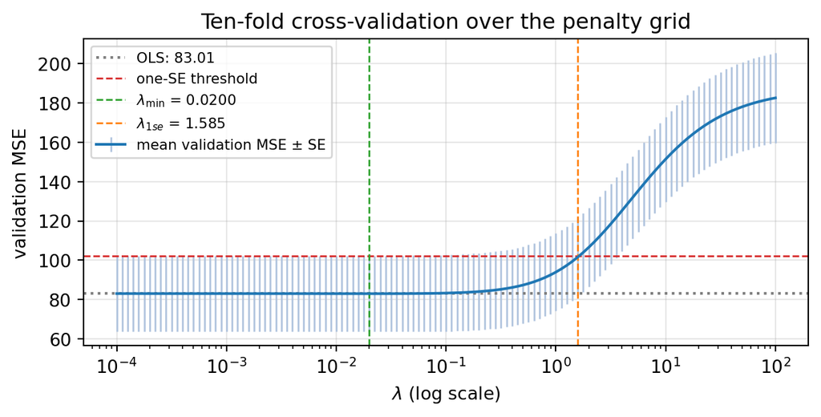

```python
K = 10
fold_mse = np.zeros((K, len(lam_grid)))
for k in range(1, K + 1):
    val = fold_id == k
    for j, lam in enumerate(lam_grid):
        pred = ridge_fit(X_tr[~val], y_tr[~val], lam)      # means/scales from the nine training folds
        fold_mse[k - 1, j] = np.mean((y_tr[val] - pred(X_tr[val])) ** 2)

cv_mean = fold_mse.mean(axis=0)
cv_se   = fold_mse.std(axis=0, ddof=1) / np.sqrt(K)

i_min   = int(cv_mean.argmin())
lam_min = lam_grid[i_min]
threshold = cv_mean[i_min] + cv_se[i_min]
i_1se   = int(np.flatnonzero(cv_mean <= threshold).max())   # largest candidate under the threshold
lam_1se = lam_grid[i_1se]

print(f"lambda_min = {lam_min:.5f}  (grid index {i_min}), CV MSE = {cv_mean[i_min]:.3f}, SE = {cv_se[i_min]:.3f}")
print(f"one-SE threshold = {threshold:.3f}")
print(f"lambda_1se = {lam_1se:.5f}  (grid index {i_1se}), CV MSE = {cv_mean[i_1se]:.3f}")
print(f"OLS (lambda = 0):  CV MSE = {cv_mean[0]:.3f}")

fig, ax = plt.subplots(figsize=(6.5, 3.4))
ax.errorbar(lam_grid[1:], cv_mean[1:], yerr=cv_se[1:], fmt="-", color="tab:blue", ecolor="lightsteelblue",
            elinewidth=1, capsize=0, label="mean validation MSE ± SE")
ax.axhline(cv_mean[0], color="gray", ls=":", label=f"OLS: {cv_mean[0]:.2f}")
ax.axhline(threshold, color="tab:red", ls="--", lw=1, label="one-SE threshold")
ax.axvline(lam_min, color="tab:green", ls="--", lw=1, label=f"$\\lambda_{{\\min}}$ = {lam_min:.4f}")
ax.axvline(lam_1se, color="tab:orange", ls="--", lw=1, label=f"$\\lambda_{{1se}}$ = {lam_1se:.3f}")
ax.set_xscale("log"); ax.set_xlabel("$\\lambda$ (log scale)"); ax.set_ylabel("validation MSE")
ax.set_title("Ten-fold cross-validation over the penalty grid")
ax.legend(fontsize=8, loc="upper left"); ax.grid(alpha=0.3)
plt.tight_layout(); plt.show()
```

The CV curve is flat from OLS out to about $\lambda\approx0.05$ and then rises steeply. The minimum is at $\lambda_{\min}=0.01995$ with mean validation MSE $82.98$, only $0.03$ below OLS’s $83.01$; the ten fold errors are quite variable (SE $=19.2$), because a few transactions have unusually high prices and whichever fold contains them has a large validation error. That large SE makes the one-SE threshold generous ($102.2$), and the largest candidate under it is $\lambda_{\mathrm{1se}}=1.585$, roughly $80$ times $\lambda_{\min}$, where the CV MSE has already climbed to $101.6$.

### (b) GCV on all 332 training observations

**Show the workflow**

```
singular values of standardized training X: [29.627837 18.848326 17.941944 14.229851 13.534164  7.16633 ]
lambda_GCV = 0.02818  (grid index 50), GCV = 83.502, df_eff = 6.689
OLS: GCV = 83.581, df_eff = 7.0
```

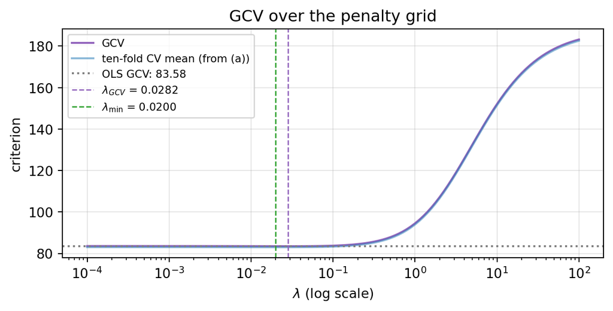

```python
n_tr = len(y_tr)
mean_all, scale_all = X_tr.mean(axis=0), X_tr.std(axis=0, ddof=0)   # estimated once, held fixed
Z_all = (X_tr - mean_all) / scale_all
y_c   = y_tr - y_tr.mean()
d_all = np.linalg.svd(Z_all, compute_uv=False)

df_eff = np.array([1 + np.sum(d_all**2 / (d_all**2 + n_tr * lam)) for lam in lam_grid])
mse_train_all = np.array([
    np.mean((y_c - Z_all @ np.linalg.solve(Z_all.T @ Z_all + n_tr * lam * np.eye(6), Z_all.T @ y_c)) ** 2)
    for lam in lam_grid])
gcv = mse_train_all / (1 - df_eff / n_tr) ** 2

i_gcv   = int(gcv.argmin())
lam_gcv = lam_grid[i_gcv]
print(f"singular values of standardized training X: {d_all}")
print(f"lambda_GCV = {lam_gcv:.5f}  (grid index {i_gcv}), GCV = {gcv[i_gcv]:.3f}, df_eff = {df_eff[i_gcv]:.3f}")
print(f"OLS: GCV = {gcv[0]:.3f}, df_eff = {df_eff[0]:.1f}")

fig, ax = plt.subplots(figsize=(6.5, 3.4))
ax.plot(lam_grid[1:], gcv[1:], color="tab:purple", label="GCV")
ax.plot(lam_grid[1:], cv_mean[1:], color="tab:blue", alpha=0.5, label="ten-fold CV mean (from (a))")
ax.axhline(gcv[0], color="gray", ls=":", label=f"OLS GCV: {gcv[0]:.2f}")
ax.axvline(lam_gcv, color="tab:purple", ls="--", lw=1, label=f"$\\lambda_{{GCV}}$ = {lam_gcv:.4f}")
ax.axvline(lam_min, color="tab:green", ls="--", lw=1, label=f"$\\lambda_{{\\min}}$ = {lam_min:.4f}")
ax.set_xscale("log"); ax.set_xlabel("$\\lambda$ (log scale)"); ax.set_ylabel("criterion")
ax.set_title("GCV over the penalty grid")
ax.legend(fontsize=8, loc="upper left"); ax.grid(alpha=0.3)
plt.tight_layout(); plt.show()
```

GCV picks $\lambda_{\mathrm{GCV}}=0.02818$, three grid steps (a factor of about $1.4$) above $\lambda_{\min}$, with $\operatorname{df}_{\mathrm{eff}}=6.69$ versus $7$ for OLS. The GCV curve tracks the ten-fold CV curve closely but is smoother, since it is computed from a single fit with an analytic correction rather than from ten noisy held-out folds. The training singular values range from $29.6$ down to $7.2$ (ratio about $4$), so this design is not ill-conditioned the way Question 2’s was; there is no near-null direction for ridge to clean up, which is why the best penalty is small and the gain over OLS is marginal.

### (c) Test-set evaluation of the four fixed choices

**Show the workflow**

```python
choices = [("OLS", 0.0, 0), ("lambda_min", lam_min, i_min), ("lambda_1se", lam_1se, i_1se), ("lambda_GCV", lam_gcv, i_gcv)]
rows = []
for name, lam, idx in choices:
    pred = ridge_fit(X_tr, y_tr, lam)
    rows.append({"model": name, "lambda": lam,
                 "train MSE": np.mean((y_tr - pred(X_tr)) ** 2),
                 "test MSE":  np.mean((y_te - pred(X_te)) ** 2),
                 "df_eff": df_eff[idx], "CV MSE": cv_mean[idx], "GCV": gcv[idx]})
tab5 = pd.DataFrame(rows).set_index("model")
tab5.round(4)
```

| model | lambda | train MSE | test MSE | df_eff | CV MSE | GCV |
| --- | --- | --- | --- | --- | --- | --- |
| OLS | 0.0000 | 80.0939 | 66.3225 | 7.0000 | 83.0124 | 83.5813 |
| lambda_min | 0.0200 | 80.1354 | 65.9996 | 6.7732 | 82.9776 | 83.5080 |
| lambda_1se | 1.5849 | 100.3736 | 81.1998 | 3.0329 | 101.5955 | 102.2329 |
| lambda_GCV | 0.0282 | 80.1713 | 65.9028 | 6.6887 | 82.9826 | 83.5019 |

**What the table shows.** OLS, $\lambda_{\min}$ and $\lambda_{\mathrm{GCV}}$ are nearly the same model: their training MSEs differ by less than $0.1$, their test MSEs by $0.4$ (between $65.9$ and $66.3$), and they spend $7.0$, $6.77$ and $6.69$ effective degrees of freedom. With $n=332$ and only six well-conditioned predictors, OLS is not overfitting, so a small penalty removes almost no variance and introduces almost no bias. $\lambda_{\mathrm{1se}}$ is a genuinely different model: it uses only $3.0$ effective degrees of freedom, its training MSE jumps from $80$ to $100$ and its test MSE from $66$ to $81$. The one-SE rule was designed to trade a little accuracy for a simpler model when the CV curve is flat and noisy, but here the SE is inflated by outlying prices, so the rule walks far up the rising part of the curve and underfits. That said, one test ordering does not refute the rule: the test-set standard error is about $11$, so $81$ versus $66$ is a difference of roughly $1.3$ SE. Training MSE is uniformly higher than test MSE for all four models, which is a reminder that a single 82-observation test set is itself a noisy estimate; the 332 training cases evidently include more of the high-price outliers than the test cases do.

**Why the smallest test MSE must not be used to choose.** The test set’s job is to give an unbiased estimate of the prediction error of a model that was chosen *without* it. The moment I look at this table and pick $\lambda_{\mathrm{GCV}}$ because $65.90 < 65.99 < 66.32$, the test set has become part of the selection procedure: I am choosing the minimum of four noisy numbers, and the minimum of noisy estimates is biased downward as an estimate of the selected model’s true error. Its reported $65.9$ would then be optimistic, exactly the optimism that cross-validation exists to avoid, and I would have no honest data left to measure it with. The differences among the top three ($0.4$ in MSE, against a fold-to-fold SE of about $19$ and a test SE of a similar order) are also far too small to distinguish the models; choosing by them would be fitting to test noise. The defensible procedure is the one in the problem statement: fix the rule ($\lambda_{\min}$, $\lambda_{\mathrm{1se}}$ or GCV) before the test responses are opened, report its test MSE once, and treat that as the final estimate. If I want to compare selection rules, the comparison has to happen inside the training data, by nested cross-validation.

## `explain-to-me` skill

The complete `explain-to-me/SKILL.md` as installed:

```markdown
---
name: explain-to-me
description: Explain what a STAT 432 homework question is asking, without solving it. Use only when the user explicitly asks to "use explain-to-me" on a question.
---

# explain-to-me

My intent: I want to understand a homework question well enough to attempt it myself. Do not solve it for me.

## When this skill runs

Only when I explicitly say something like "use explain-to-me on Question N". Otherwise ignore this skill and do not change how you normally work.

## What to do

1. Read the question I point to, from the homework file in the repo or from the URL I give.
2. Restate the goal in two or three plain sentences: what is being estimated, compared, or shown, and why the course cares.
3. List the deliverables as a checklist: every number, table, plot, derivation, or written interpretation the question asks for, part by part.
4. Name the inputs I must get right: seeds, sample sizes, scaling conventions, which formula variant (for example n*lambda vs lambda), what is held fixed and what is redrawn.
5. Point me to the one or two most relevant sections of the Week 3 lectures:
   - Ridge Regression: Stability Through Shrinkage
     https://teazrq.github.io/stat432rpy/topics/ridge-regression/ridge-regression.html
   - From a Penalized Objective to a Fitted Ridge Model
     https://teazrq.github.io/stat432rpy/topics/ridge-regression/optimization-and-cross-validation.html
   Say which section heading, and one sentence on why it applies.
6. End with one question back to me that checks whether I understood the point of the problem.

## Rules

- No code, no derivations, no numerical answers, no "expected results". If I ask for those, remind me that this skill is for understanding only and stop.
- Do not read or mention the solutions file.
- Keep it under 300 words. Use plain language first; introduce notation only where the question uses it.
- If the question is ambiguous, say what is ambiguous rather than picking an interpretation silently.
```